# 05 · Automatización de copias de seguridad

## Automatización de copias de seguridad

05 · COPIAS VERSIONADAS, INTEGRIDAD Y RESTAURACIÓN

Automatización de  
copias de seguridad

**De crear archivos a demostrar que podemos recuperarlos**

Caso conductor: recuperar un proyecto de informes sintéticos.

Datos de aula completamente ficticios.

## La entrega es una recuperación demostrable

Crear copias es una actividad. Recuperar datos útiles es el resultado.

Al finalizar podrás definir objetivos, generar versiones completas, detectar alteraciones, restaurar a un destino nuevo y justificar una política de retención.

## Alcance del bloque 05

| Aquí | Después |
| --- | --- |
| Copias completas, manifiestos y restauración. | Organizador inteligente: proyecto del bloque 06. |
| Incrementales y diferenciales: teoría y capacidad. | Excel, PDF y otros formatos especializados. |
| Retención y evidencia de recuperación. | APIs, correo, IA y agentes. |

## ¿Qué problema resuelve cada herramienta?

| Operación | Comportamiento que hay que comprobar |
| --- | --- |
| Sincronización | Puede propagar cambios y borrados. |
| Espejo | Busca reflejar un estado; puede eliminar históricos. |
| Copia versionada | Conserva estados anteriores seleccionables. |
| Archivo | Conserva información según una finalidad y política. |

## Inventario antes de automatizar

Incluye datos, configuración, código y dependencias de recuperación.

Identifica propietario, criticidad, tamaño, frecuencia de cambio y ubicación. Decide qué se excluye y por qué.

## Escenarios de pérdida y dominios de fallo

| Incidente | Pregunta de diseño |
| --- | --- |
| Borrado accidental | ¿Existe una versión anterior? |
| Disco averiado | ¿La copia está en otro soporte? |
| Robo o incendio | ¿Hay una ubicación independiente? |
| Cuenta comprometida | ¿Puede borrar también las copias? |

## 3-2-1 como pauta de diseño

Tres copias de los datos, incluida la de trabajo; dos tipos de soporte; una copia fuera de la ubicación principal.

Añade aislamiento offline o inmutabilidad y pruebas de restauración según el riesgo.

## RPO: cuánta pérdida de datos toleramos

El **Recovery Point Objective** fija el punto de recuperación requerido: cuánto retroceso temporal tolera el proceso.

$$A=t_{incidente}-t_{último\ estado\ recuperable}$$

La antigüedad real $A$ debe contrastarse con el RPO acordado.

## La tarea fallida también cuenta

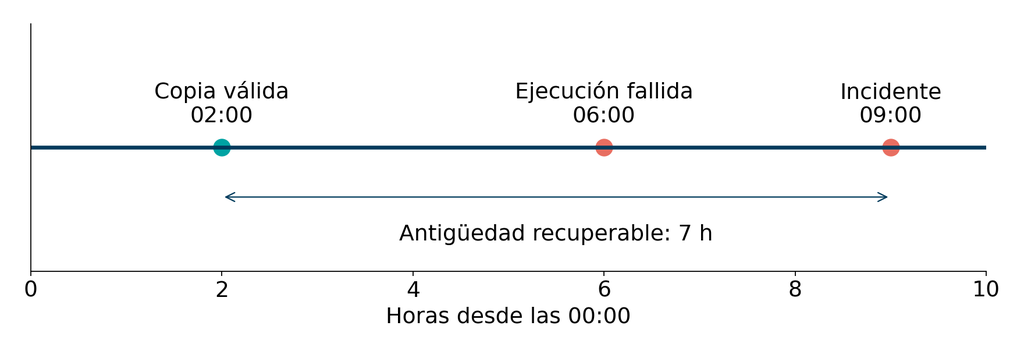

Un calendario de cuatro horas no evita siete horas de retroceso si la ejecución de las 06:00 no dejó una copia recuperable.

## Frecuencia y pérdida esperada

Si todas las copias tienen éxito y el incidente es uniforme entre ejecuciones separadas por $\Delta$:

$$A_{máx}\approx\Delta,\qquad E[A]=\frac{\Delta}{2}$$

Son hipótesis del modelo, no una promesa de servicio.

## RTO: tiempo hasta recuperar el servicio

El **Recovery Time Objective** fija el tiempo objetivo de recuperación del proceso.

Incluye decisión, preparación del entorno, transferencia, comprobación y aceptación del servicio.

## Estimación de transferencia y tiempo total

$$T_{transferencia}\approx\frac{V}{v}$$

100 GiB a 100 MiB/s: 1.024 s ≈ 17,1 min.

Con 5 min de preparación y 8 min de comprobación: **≈ 30,1 min**, antes de otros pasos del proceso.

## Completa, incremental y diferencial

| Estrategia | Copia cambios desde | Recuperación del último estado |
| --- | --- | --- |
| Completa | Todo el conjunto | Una generación completa. |
| Incremental | Copia anterior | Base + cadena de incrementales. |
| Diferencial | Última completa | Base + último diferencial. |

## Comparación con hipótesis explícitas

Conjunto fijo de 10 GiB. Seis días con 1 GiB de cambios disjuntos por día. Siete puntos de recuperación, incluida la base.

Sin compresión, deduplicación ni crecimiento del conjunto.

## Capacidad: el ahorro tiene dependencias

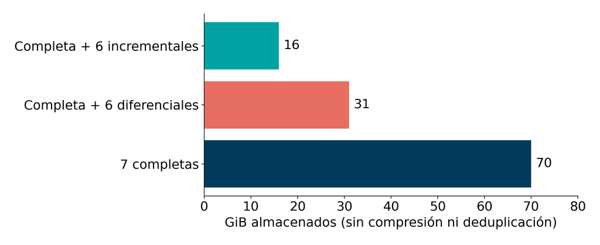

## Compresión, cifrado y deduplicación

La compresión reduce redundancia. El cifrado protege confidencialidad. La deduplicación evita guardar contenido repetido.

Ninguna de estas propiedades demuestra por sí sola que una copia sea restaurable.

## Consistencia: copiar un archivo vivo

Un archivo puede cambiar entre inventario y lectura. Varios archivos pueden pertenecer a una misma transacción.

Detén las escrituras o utiliza exportaciones o snapshots compatibles con la aplicación.

## Contrato del motor de aula

Copias completas de archivos regulares en un proyecto sintético privado. Origen en reposo.

Máximo 1.000 archivos, 10 MiB por archivo y 50 MiB de contenido total. Sin enlaces, recursos especiales ni carpetas vacías.

| Contenido | Uso en la comprobación |
| --- | --- |
| CSV de importes ficticios | Lectura y tipos de datos. |
| JSON de territorios y parámetros | Claves y configuración. |
| Markdown de informe | Documento legible. |
| Archivo vacío | Un archivo de cero bytes también cuenta. |

## Inventario determinista

```python
filas = inventariar(proyecto / "origen")
for fila in filas:
    print(fila["ruta"], fila["bytes"], fila["sha256"])
```

Rutas relativas, tamaño y SHA-256. Orden estable y rechazo de colisiones de nombres al ignorar mayúsculas.

## SHA-256: una huella de los bytes

$$h=SHA256(b_1,b_2,\ldots,b_n)$$

Dos archivos con igual tamaño pueden tener huellas diferentes. El hash no sustituye la lectura del formato ni la validación del negocio.

## Leer por bloques, no cargarlo todo

```python
h = hashlib.sha256()
with ruta.open("rb") as f:
    while bloque := f.read(64 * 1024):
        h.update(bloque)
print(h.hexdigest())
```

## Qué contiene el manifiesto

Identidad de generación, fecha UTC, versión del motor, tipo completa y lista de archivos con ruta, bytes y SHA-256.

La suma de tamaños debe coincidir con el total declarado. Se rechazan claves duplicadas y campos inesperados.

## Integridad no es autenticidad

Si alguien cambia contenido y manifiesto de forma coherente, un hash sin firma no identifica al autor del cambio.

Protege las referencias, los permisos y las credenciales. Firma o autentica cuando el modelo de amenaza lo requiera.

## Publicar solo después de comprobar

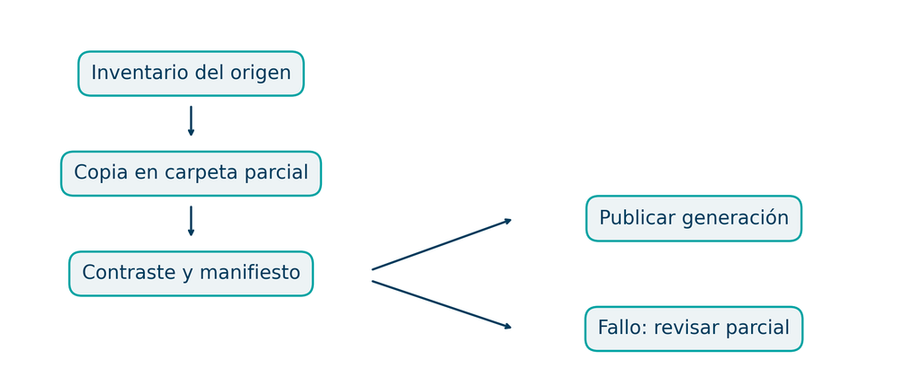

## Por qué se conserva un parcial fallido

Los nombres `.parcial_...` no son generaciones publicadas. Se excluyen de la retención automática.

Tras un fallo, revisa causa, espacio y contenido antes de una limpieza deliberada.

## Bloqueo local cooperante

Un archivo exclusivo en estado evita dos escritores cooperantes del mismo proyecto. El token permite retirar solo el bloqueo propio.

Un bloqueo huérfano exige diagnóstico; no se retira automáticamente por antigüedad.

## Crear: primero simular

```bash
python copias_seguridad.py crear --proyecto "demo"
python copias_seguridad.py crear --proyecto "demo" --aplicar
```

Sin `--aplicar`, el motor inventaría y presenta el plan sin publicar una copia.

## Verificar: reconciliar, no confiar

```bash
python copias_seguridad.py verificar \
  --proyecto "demo" --copia "ID_DEVUELTO_AL_CREAR"
```

Se detectan archivos ausentes, adicionales, tamaños y huellas diferentes.

## Restaurar en un destino nuevo

```bash
python copias_seguridad.py restaurar \
  --proyecto "demo" --copia "ID_DEVUELTO_AL_CREAR" \
  --destino "ensayo_01" --aplicar
```

El destino vive en `restauraciones/` y debe ser nuevo.

## Tres niveles de aceptación

| Nivel | Evidencia |
| --- | --- |
| Estructura | Están todos los elementos previstos. |
| Bytes | Tamaños y SHA-256 coinciden. |
| Uso | La aplicación abre y utiliza los datos recuperados. |

## Medir sin llamar RTO a todo

El motor devuelve `duracion_transferencia_y_contraste_s`.

El simulacro documenta aparte detección, decisión, preparación, lectura de datos y aceptación del proceso.

## La pregunta que evita falsas certezas

[figure not shown]

## Retención: qué estados necesitamos

Define cuántos estados, qué antigüedades y qué capacidad necesitas. Incluye errores descubiertos tarde.

Conservar dos generaciones no equivale a conservar dos días.

## Rotaciones diarias, semanales y mensuales

Una política tipo abuelo-padre-hijo combina puntos recientes y antiguos.

Distingue calendario, capacidad, dependencias de cadenas y finalidad de conservación.

## Retención conservadora en el laboratorio

Primero valida todas las generaciones reconocidas. Ordena por fecha UTC declarada. Conserva al menos una.

Una generación reconocida inválida aborta el plan antes de retirar otras. Carpetas desconocidas y parciales quedan fuera.

## Revisar el plan antes de retirar

```bash
python copias_seguridad.py retencion \
  --proyecto "demo" --conservar 2
# Solo tras revisar el plan del laboratorio:
python copias_seguridad.py retencion \
  --proyecto "demo" --conservar 2 --aplicar
```

## Privacidad y claves de recuperación

Las copias replican información: limita acceso, protege soportes y define la finalidad de conservación.

Custodia las claves por separado y ensaya su recuperación mediante el procedimiento autorizado.

## Windows: Robocopy como pieza del proceso

```powershell
robocopy "C:\Aula\origen" "E:\Aula\version_01" `
  /E /L /R:1 /W:1 /COPY:DAT /XJ
```

`/L` solo enumera. `/E` incluye carpetas vacías. `/COPY:DAT` solicita datos, atributos y fechas.

## Robocopy: dos trampas frecuentes

`/MIR` incluye purga: puede eliminar elementos del destino. `/MOV` y `/MOVE` retiran elementos del origen.

Códigos 0–7 no indican necesariamente fallo de copia; **8 o más** indican al menos un fallo.

## macOS: Time Machine y restauración

Time Machine permite copias y recuperación de estados anteriores. Practica seleccionar una fecha y recuperar un elemento en un entorno preparado.

Los snapshots locales no sustituyen una copia independiente del disco.

## Linux: rsync y el significado del destino

```bash
rsync -a --dry-run --itemize-changes \
  "/ruta/aula/origen/" "/ruta/aula/version_01/"
```

La barra final del origen copia su contenido. El quick check habitual compara tamaño y fecha; no equivale a nuestro manifiesto SHA-256.

## Comparar herramientas por contrato

| Pregunta | Evidencia que pedir |
| --- | --- |
| ¿Qué protege? | Archivos, metadata y consistencia admitidas. |
| ¿Dónde guarda? | Soporte, ubicación y credenciales. |
| ¿Cómo recupera? | Procedimiento y ensayo reproducible. |
| ¿Cómo limpia? | Política y dependencias verificadas. |

## Reutilizar la programación del bloque 04

Entrega al planificador el intérprete absoluto, el script absoluto y el proyecto absoluto. Captura stdout, stderr y código de salida.

El calendario inicia la copia; una verificación y una alerta permiten operar el proceso.

## Códigos de salida del motor

| Código | Significado |
| --- | --- |
| 0 | Operación correcta, incluida simulación. |
| 10 | Fallo de integridad. |
| 20 | Contrato del proyecto o argumento semántico. |
| 30 | Fallo operativo inesperado. |
| 40 | Bloqueo ocupado. |
| 2 | Uso inválido de argparse. |

## Alertas con significado operativo

Comprueba última generación recuperable, edad, espacio, fallos consecutivos y fecha del último ensayo.

Una alerta debe indicar responsable, evidencia y siguiente acción.

## Laboratorio: secuencia guiada

1. Crear proyecto temporal sintético.
2. Inventariar y simular.
3. Publicar una copia verificada.
4. Restaurar a carpeta nueva y leer los datos.
5. Provocar fallos y revisar la retención.

## Ejercicios 01–04: definir y observar

1. Inventario: archivos vacíos y carpetas vacías.
2. Alteración con el mismo tamaño y SHA-256.
3. RPO y estimación temporal con unidades coherentes.
4. Simulación sin publicar ninguna generación.

## Ejercicios 05–08: recuperar y fallar

5. Crear y verificar una generación.
6. Restaurar y leer CSV y JSON.
7. Recuperar un archivo borrado de la demo.
8. Detectar corrupción y rechazar la restauración.

## Ejercicios 09–12: operación controlada

9. CLI con rutas absolutas y otro directorio actual.
10. Rutas peligrosas y nombres incompatibles.
11. Plan y aplicación de retención dentro de la demo.
12. Retención bloqueada por una copia inválida.

## Evidencias para evaluar

Inventario esperado, generación publicada, verificación, lectura de archivos restaurados, fallo detectado y plan de retención explicado.

Añade un procedimiento de recuperación que otra persona pueda seguir.

## Límites que deben acompañar a la entrega

Laboratorio local sin cifrado ni autenticidad criptográfica. No conserva ACL, enlaces ni directorios vacíos. No es snapshot ni solución 3-2-1.

Windows, macOS y herramientas nativas requieren ensayo propio; la verificación ejecutada se detalla en VERIFICACION.md.

## Fuentes primarias: diseño y recuperación

[NIST SP 800-34 Rev. 1](https://nvlpubs.nist.gov/nistpubs/legacy/sp/nistspecialpublication800-34r1.pdf): planificación de contingencia, RPO y RTO.

[CISA, guía StopRansomware](https://www.cisa.gov/sites/default/files/2023-10/StopRansomware-Guide-508C-v3_1.pdf): copias aisladas y ensayos.

[Python 3.11: hashlib](https://docs.python.org/3.11/library/hashlib.html) y [shutil](https://docs.python.org/3.11/library/shutil.html).

## Fuentes primarias: herramientas nativas

[Microsoft: Robocopy](https://learn.microsoft.com/en-us/windows-server/administration/windows-commands/robocopy).

[Apple: Time Machine](https://support.apple.com/en-gb/guide/mac-help/mh35860/mac).

[rsync: manual oficial](https://rsync.samba.org/ftp/rsync/rsync.1).